# PAC 1 ANALISIS MULTIVARIANTE

Raul Perez Prats

2024-10-27

## EJERCICIO 1

### A)

```
##   r gravity   ph osmo cond urea calc
## 1 0   1.021 4.91  725   NA  443 2.45
## 2 0   1.017 5.74  577 20.0  296 4.49
## 3 0   1.008 7.20  321 14.9  101 2.36
## 4 0   1.011 5.51  408 12.6  224 2.15
## 5 0   1.005 6.52  187  7.5   91 1.16
## 6 0   1.020 5.27  668 25.3  252 3.34
```

Observamos el head del dataset. Las filas corresponden a los diferentes muestreos y en las columnas a las variables muestreadas.

```
##        r             gravity            ph             osmo
##  Min.   :0.0000   Min.   :1.005   Min.   :4.760   Min.   : 187.0
##  1st Qu.:0.0000   1st Qu.:1.012   1st Qu.:5.530   1st Qu.: 411.5
##  Median :0.0000   Median :1.018   Median :5.940   Median : 612.5
##  Mean   :0.4304   Mean   :1.018   Mean   :6.028   Mean   : 615.0
##  3rd Qu.:1.0000   3rd Qu.:1.024   3rd Qu.:6.385   3rd Qu.: 797.5
##  Max.   :1.0000   Max.   :1.040   Max.   :7.940   Max.   :1236.0
##                                                   NA's   :1
##       cond            urea            calc
##  Min.   : 5.10   Min.   : 10.0   Min.   : 0.170
##  1st Qu.:14.38   1st Qu.:160.0   1st Qu.: 1.460
##  Median :21.40   Median :260.0   Median : 3.160
##  Mean   :20.90   Mean   :266.4   Mean   : 4.139
##  3rd Qu.:26.77   3rd Qu.:372.0   3rd Qu.: 5.930
##  Max.   :38.00   Max.   :620.0   Max.   :14.340
##  NA's   :1
```

Se trata de un dataset de 79 observaciones y 7 variables todas ellas continuas excepto la variable ‘r’ que corresponde a la presencia/absencia de oxalato de calcio.

```
## [1] "Posición de valores faltantes "
```

```
## [1] 292 317
```

```
## [1] "Número de valores faltantes según variables:"
```

```
##       r gravity      ph    osmo    cond    urea    calc
##       0       0       0       1       1       0       0
```

```
## [1] "Número total de valores faltantes"
```

```
## [1] 2
```

Encontramos 2 valores faltantes pertenencientes a las variables ‘osmo’ y ‘cond’

```
##        r             gravity            ph             osmo
##  Min.   :0.0000   Min.   :1.005   Min.   :4.760   Min.   : 187.0
##  1st Qu.:0.0000   1st Qu.:1.012   1st Qu.:5.530   1st Qu.: 413.0
##  Median :0.0000   Median :1.018   Median :5.940   Median : 631.0
##  Mean   :0.4304   Mean   :1.018   Mean   :6.028   Mean   : 615.2
##  3rd Qu.:1.0000   3rd Qu.:1.024   3rd Qu.:6.385   3rd Qu.: 792.0
##  Max.   :1.0000   Max.   :1.040   Max.   :7.940   Max.   :1236.0
##       cond            urea            calc
##  Min.   : 5.10   Min.   : 10.0   Min.   : 0.170
##  1st Qu.:14.45   1st Qu.:160.0   1st Qu.: 1.460
##  Median :21.40   Median :260.0   Median : 3.160
##  Mean   :20.91   Mean   :266.4   Mean   : 4.139
##  3rd Qu.:26.55   3rd Qu.:372.0   3rd Qu.: 5.930
##  Max.   :38.00   Max.   :620.0   Max.   :14.340
```

Si hacemos otro print del summary nos muestra que ya no hay valores nulos

### B)

```r
#dividimos en subgrupos
group_0 <- subset(urine_imputed, r == 0)
group_1 <- subset(urine_imputed, r == 1)

#Calcular los vectores de medias y matrices de varianzas-covarianzas para cada grupo
mean_group_0 <- colMeans(group_0, na.rm = TRUE)
mean_group_1 <- colMeans(group_1, na.rm = TRUE)

cov_group_0 <- cov(group_0, use = "complete.obs")
cov_group_1 <- cov(group_1, use = "complete.obs")

#Calcular la variación total sumando las trazas de las matrices de varianzas-covarianzas
total_variation <- sum(diag(cov_group_0)) + sum(diag(cov_group_1))

#Calcular la varianza generalizada
gen_var_group_0 <- det(cov_group_0)
gen_var_group_1 <- det(cov_group_1)

#Evaluación visual de la similitud en la variabilidad de ambos grupos
list(
  mean_group_0 = mean_group_0,
  mean_group_1 = mean_group_1,
  cov_group_0 = cov_group_0,
  cov_group_1 = cov_group_1,
  variation_0 = sum(diag(cov_group_0)),
  variation_1 = sum(diag(cov_group_1)),
  total_variation = total_variation,
  gen_var_group_0 = gen_var_group_0,
  gen_var_group_1 = gen_var_group_1
)
```

```
## $mean_group_0
##          r    gravity         ph       osmo       cond       urea       calc
##   0.000000   1.015489   6.098667 565.288889  20.568889 237.111111   2.624889
##
## $mean_group_1
##          r    gravity         ph       osmo       cond       urea       calc
##   1.000000   1.021588   5.935588 681.352941  21.355882 305.176471   6.142941
##
## $cov_group_0
##         r       gravity            ph         osmo          cond          urea
## r       0  0.000000e+00   0.000000000     0.000000    0.00000000     0.0000000
## gravity 0  3.766465e-05  -0.001098652     1.372106    0.04121783     0.6597626
## ph      0 -1.098652e-03   0.492857273   -43.236879   -0.76186061   -33.2114394
## osmo    0  1.372106e+00 -43.236878788 54369.982828 1803.53191919 24393.4217172
## cond    0  4.121783e-02  -0.761860606  1803.531919   76.58673737   573.1171717
## urea    0  6.597626e-01 -33.211439394 24393.421717  573.11717172 15062.7828283
## calc    0  4.676419e-03  -0.180200152   201.101510    7.36567828   102.3335354
##                  calc
## r         0.000000000
## gravity   0.004676419
## ph       -0.180200152
## osmo    201.101510101
## cond      7.365678283
## urea    102.333535354
## calc      3.470739192
##
## $cov_group_1
##         r       gravity            ph         osmo          cond          urea
## r       0  0.000000e+00   0.000000000     0.000000    0.00000000     0.0000000
## gravity 0  5.182531e-05  -0.001091266     1.278513    0.01882068     0.7261658
## ph      0 -1.091266e-03   0.567261765   -27.321729   -0.48729144   -11.1234403
## osmo    0  1.278513e+00 -27.321729055 52053.083779 1187.58270945 27786.5418895
## cond    0  1.882068e-02  -0.487291444  1187.582709   45.07769162   464.1777184
## urea    0  7.261658e-01 -11.123440285 27786.541889  464.17771836 17917.4830660
## calc    0  1.049731e-02  -0.089913904   449.614991    9.64952763   231.0712834
##                 calc
## r         0.00000000
## gravity   0.01049731
## ph       -0.08991390
## osmo    449.61499109
## cond      9.64952763
## urea    231.07128342
## calc     13.22926988
##
## $variation_0
## [1] 69513.32
##
## $variation_1
## [1] 70029.44
##
## $total_variation
## [1] 139542.8
##
## $gen_var_group_0
## [1] 0
##
## $gen_var_group_1
## [1] 0
```

Si observamos los vectores de las medias de cada grupo podemos ver a simple vista que existen diferencias en las variables ‘ph’, ‘osmo’, ‘urea’ y ‘calc’. Estas diferencias son notables a simple vista, aunque hace falta hacer un análisis estadístico más profundo para determinar el impacto y de estas variaciones y si son realmente significativas.

Si sumamos las trazas de la matriz de covarianzas de cada grupo obtenemos la variación para cada grupo. Vemos que en ambos grupos la varianza es similar, aproximadamente de 70000, aunque la varianza del grupo 1 es superior.

### C)

```r
library(pcaPP)

# Calcular las medianas geométricas de cada grupo
geom_median_group_0 <- l1median(group_0)
geom_median_group_1 <- l1median(group_1)

# Calcular la distancia euclídea entre los puntos medios
distance_means <- sqrt(sum((mean_group_0 - mean_group_1)^2))

# Calcular la distancia euclídea entre las medianas geométricas
distance_geom_medians <- sqrt(sum((geom_median_group_0 - geom_median_group_1)^2))

# Resultados
list(
  geom_median_group_0 = geom_median_group_0,
  geom_median_group_1 = geom_median_group_1,
  distance_means = distance_means,
  distance_geom_medians = distance_geom_medians
)
```

```
## $geom_median_group_0
## [1]   0.000000   1.015329   6.114318 560.043466  20.905290 228.217668   2.453924
##
## $geom_median_group_1
## [1]   1.000000   1.022487   6.256926 715.261304  23.431986 314.632592   7.575486
##
## $distance_means
## [1] 134.6023
##
## $distance_geom_medians
## [1] 177.7463
```

La distancia euclídea entre las medias aritméticas de los dos grupos es de 134.6023. Este valor indica que los centros de los dos grupos, medidos por sus medias, están relativamente alejados en el espacio multidimensional de las variables. Es un valor considerable, lo que sugiere que las medias de los dos grupos no son similares.

La distancia euclídea entre las medianas geométricas es 177.7463. Esta distancia es mayor que la de las medias (134.6023), lo que indica que las posiciones centrales de los dos grupos, basadas en las medianas geométricas, están aún más separadas que cuando se utilizan las medias aritméticas.

A diferencia de la media aritmética, que es sensible a valores extremos (outliers), la mediana geométrica es más robusta, lo que significa que no se ve tan afectada por puntos atípicos en los datos, ya que busca el “punto central” de un conjunto de datos en un espacio de múltiples dimensiones de una manera robusta, minimizando las distancias a todos los puntos del conjunto.

Por lo tanto, según la mediana geométrica, los grupos son más distantes en cuanto a su centralidad.

### D)

```r
library(MASS)

# Fijamos la semilla
set.seed(123)

# Estimadores robustos de medias y matrices de covarianzas para cada grupo
# Para medias, usamos la mediana robusta (estimador robusto de centralidad)
# Para la covarianza, usamos el estimador robusto de covarianza de M-estimación.

# Función para eliminar columnas con valores constantes
remove_constant_columns <- function(data) {
  # Identificar columnas que tienen IQR = 0
  constant_columns <- sapply(data, function(col) IQR(col, na.rm = TRUE) == 0)
  # Eliminar las columnas constantes
  data_cleaned <- data[, !constant_columns]
  return(data_cleaned)
}

# Limpiar los grupos eliminando columnas constantes
group_0_clean <- remove_constant_columns(group_0)
group_1_clean <- remove_constant_columns(group_1)

# Estimadores robustos de medias y covarianzas para los grupos limpiados
mean_group_0_robust <- apply(group_0_clean, 2, function(col) median(col, na.rm = TRUE))
cov_group_0_robust <- cov.rob(group_0_clean)$cov

mean_group_1_robust <- apply(group_1_clean, 2, function(col) median(col, na.rm = TRUE))
cov_group_1_robust <- cov.rob(group_1_clean)$cov

# Función para calcular la distancia de Mahalanobis utilizando estimadores robustos
mahalanobis_dist <- function(data, mean_robust, cov_robust) {
  d <- apply(data, 1, function(x) {
    diff <- x - mean_robust
    sqrt(t(diff) %*% solve(cov_robust) %*% diff)
  })
  return(d)
}

# Calcular la distancia de Mahalanobis para cada grupo limpio
mahalanobis_group_0 <- mahalanobis_dist(group_0_clean, mean_group_0_robust, cov_group_0_robust)
mahalanobis_group_1 <- mahalanobis_dist(group_1_clean, mean_group_1_robust, cov_group_1_robust)

# Establecer un umbral para detectar los puntos atípicos
threshold <- 3

# Detectar los puntos atípicos en cada grupo
outliers_group_0 <- which(mahalanobis_group_0 > threshold)
outliers_group_1 <- which(mahalanobis_group_1 > threshold)

# Resultados
list(
  outliers_group_0 = outliers_group_0,
  outliers_group_1 = outliers_group_1,
  mahalanobis_group_0 = mahalanobis_group_0,
  mahalanobis_group_1 = mahalanobis_group_1
)
```

```
## $outliers_group_0
##  1  3  4  8 10 12 13 14 15 16 17 18 19 22 23 24 26 27 29 31 32 34 35 38 39 40
##  1  3  4  8 10 12 13 14 15 16 17 18 19 22 23 24 26 27 29 31 32 34 35 38 39 40
## 41 42 45
## 41 42 45
##
## $outliers_group_1
## 47 49 51 54 55 57 58 59 63 68 69 70 71 73 74 75 76 78
##  2  4  6  9 10 12 13 14 18 23 24 25 26 28 29 30 31 33
##
## $mahalanobis_group_0
##         1         2         3         4         5         6         7         8
##  4.938192  2.270921  3.311081  3.549221  2.755381  1.845004  2.631816  4.565371
##         9        10        11        12        13        14        15        16
##  2.635178  3.836680  2.109268  5.688336  3.256445  3.856979  3.870439  3.602016
##        17        18        19        20        21        22        23        24
##  3.006350  5.429529 10.803570  2.259764  2.964916  3.107691  4.509190  7.805832
##        25        26        27        28        29        30        31        32
##  2.383735  5.200405  5.266435  2.602631  3.791988  2.696225  5.558132  3.437715
##        33        34        35        36        37        38        39        40
##  2.968038  3.588494  4.152119  1.903216  2.862682  3.864388  3.915472  4.291115
##        41        42        43        44        45
##  5.529789  3.319338  2.608944  2.424598  4.396623
##
## $mahalanobis_group_1
##        46        47        48        49        50        51        52        53
##  2.248328  3.267220  1.713405  3.528430  1.446964  3.049974  2.256403  2.593750
##        54        55        56        57        58        59        60        61
##  3.031202  8.036506  2.069800  4.811955  3.194096  9.334785  2.705175  1.538070
##        62        63        64        65        66        67        68        69
##  2.867663  7.167802  2.159751  1.413020  2.095958  2.228938  4.143569  3.236070
##        70        71        72        73        74        75        76        77
##  3.320224 15.517616  2.100830  3.497748  3.402302  3.548527  6.366577  1.446817
##        78        79
##  3.961928  2.423795
```

Se han identificado múltiples puntos atípicos en ambos grupos, lo que sugiere que existen observaciones que se alejan significativamente de la distribución general de cada grupo.

Las distancias de Mahalanobis más altas corresponden a puntos más alejados de la media multivariada de cada grupo. Estos puntos son los que se consideran atípicos porque su valor es mucho mayor que el de la mayoría de los puntos en el grupo, según este tipo de medida de dispersión.

El grupo 0 tiene puntos con distancias más variadas (entre 1.8 y 10.8), lo que podría sugerir más variabilidad en términos de la distribución de los datos.

En el grupo 1 las distancias también varían, el grupo tiene algunos valores extremadamente altos (por ejemplo, 15.5 en el índice 71), lo que indica que algunos puntos están mucho más alejados de la media del grupo en comparación con el grupo 0.

### E)

```r
# Número total de observaciones y número de grupos
n_total <- nrow(urine)  # Total de observaciones
k <- length(unique(urine$r))  # Número de grupos (en este caso, 2)

# Tamaño de cada grupo
n_group_0 <- nrow(group_0)
n_group_1 <- nrow(group_1)

# Matrices de covarianzas para cada grupo
cov_group_0 <- cov(group_0, use = "complete.obs")
cov_group_1 <- cov(group_1, use = "complete.obs")

# Cálculo de la matriz de covarianzas combinadas (pooled)
SP <- ((n_group_0 - 1) * cov_group_0 + (n_group_1 - 1) * cov_group_1) / (n_total - k)

# Matriz de covarianzas total (combinada para todo el conjunto de datos)
cov_total <- cov(urine, use = "complete.obs")

# Cálculo de la lambda de Wilks
W <- (n_total - k) * SP
T <- (n_total - 1) * cov_total
lambda_wilks <- det(W) / det(T)

# Resultado
list(
  pooled_covariance_matrix = SP,
  wilks_lambda = lambda_wilks
)
```

```
## $pooled_covariance_matrix
##         r       gravity            ph         osmo          cond          urea
## r       0  0.0000000000   0.000000000     0.000000    0.00000000     0.0000000
## gravity 0  0.0000437335  -0.001095486     1.331995    0.03161905     0.6882211
## ph      0 -0.0010954861   0.524744912   -36.416100   -0.64418811   -23.7451541
## osmo    0  1.3319946185 -36.416100331 53377.026093 1539.55368644 25847.6160767
## cond    0  0.0316190493  -0.644188108  1539.553686   63.08286062   526.4288346
## urea    0  0.6882211188 -23.745154062 25847.616077  526.42883456 16286.2257873
## calc    0  0.0071710860  -0.141506045   307.607288    8.34447086   157.5068560
##                  calc
## r         0.000000000
## gravity   0.007171086
## ph       -0.141506045
## osmo    307.607287667
## cond      8.344470860
## urea    157.506855955
## calc      7.652966628
##
## $wilks_lambda
## [1] 0
```

La lambda de Wilks es una estadística que toma valores entre 0 y 1. Valores cercanos a 0 indican que las medias de los grupos son significativamente diferentes entre sí. Valores cercanos a 1 sugieren que no hay diferencias significativas entre los grupos en términos de las variables consideradas.

Esto quiere decir que estas variables estan altamente correlacionadas en ambos grupos

### F)

```r
data <- scale(urine_imputed)  # Estandariza los datos

# Realizar PCA
pca_result <- prcomp(data, center = TRUE, scale. = TRUE)

# Criterio de Kaiser: Seleccionar componentes con autovalores > 1
eigenvalues <- pca_result$sdev^2
kaiser_criteria <- sum(eigenvalues > 1)

# Varianza explicada: Calcular el porcentaje acumulado de la varianza
explained_variance <- cumsum(eigenvalues) / sum(eigenvalues)
var_80 <- which(explained_variance >= 0.80)[1]

# Mostrar la varianza explicada por las tres primeras componentes

cat("Varianza explicada en las 3 primeras variables:", explained_variance[3], "\n")
```

```
## Varianza explicada en las 3 primeras variables: 0.851173
```

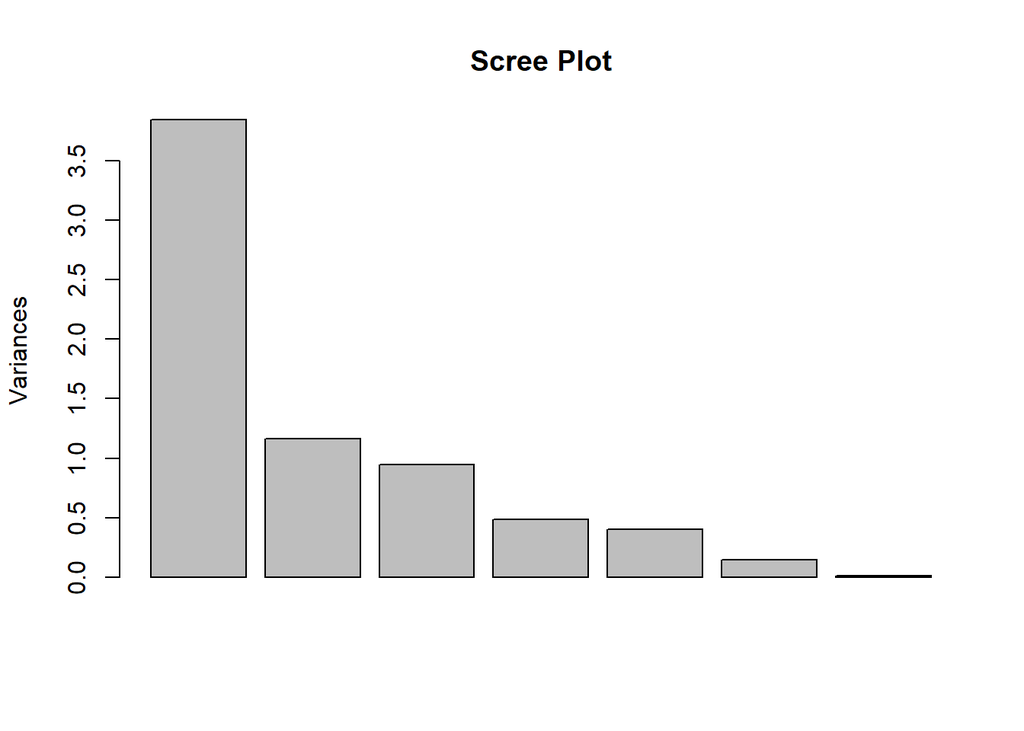

```r
# Scree Plot: Graficar el Scree plot
screeplot(pca_result, main = "Scree Plot")
```

```r
# Criterio de interpretabilidad: Inspeccionar las cargas de cada componente
loadings <- pca_result$rotation

# Imprimir los resultados
cat("Número de componentes según el criterio de Kaiser:", kaiser_criteria, "\n")
```

```
## Número de componentes según el criterio de Kaiser: 2
```

```r
cat("Número de componentes para el 80% de la varianza:", var_80, "\n")
```

```
## Número de componentes para el 80% de la varianza: 3
```

Según el criterio de Kaiser, deberíamos seleccionar las primeras dos componentes principales, ya que sus valores propios son superiores a 1.

Según la varianza explicada, para obtener más del 80% de la varianza total, es necesario elegir las tres primeras componentes principales.

De acuerdo con el scree plot, el codo se encuentra después de la primera componente principal, lo que sugiere que las primeras componentes son las que explican la mayor parte de la varianza en los datos.

Finalmente, dado que es posible realizar representaciones gráficas en tres dimensiones, la opción más completa, que explica la mayor parte de la varianza y mantiene una representación espacial comprensible, es seleccionar las tres primeras componentes principales.

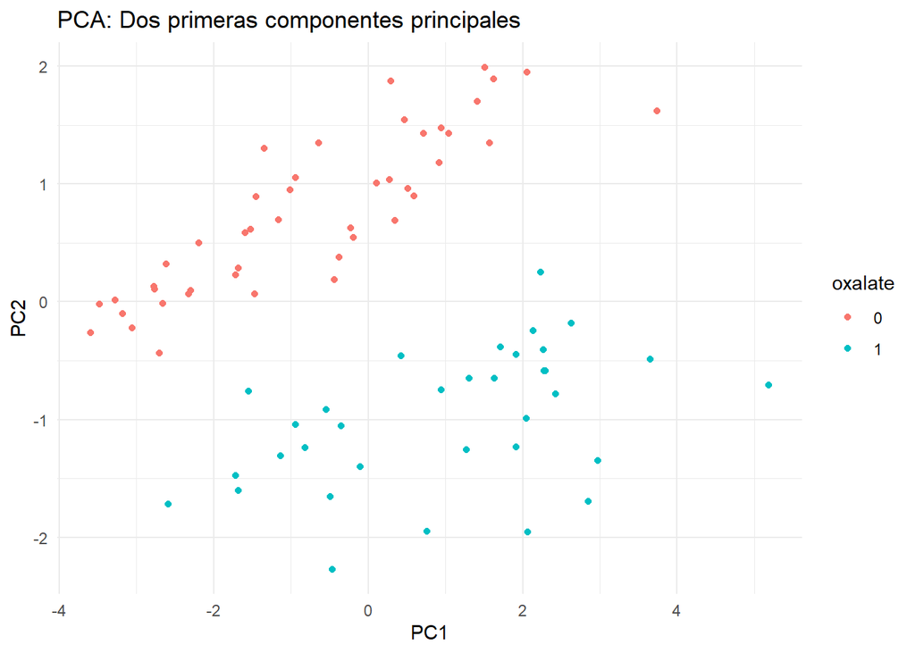

```r
# Cargamos la biblioteca necesaria para los gráficos
library(ggplot2)
library(rgl)

# Realizamos el análisis de componentes principales (PCA)
pca_result <- prcomp(data, scale. = TRUE)

# Extraemos las dos primeras componentes principales
pca_data_2d <- data.frame(PC1 = pca_result$x[,1], PC2 = pca_result$x[,2], oxalate = factor(urine_imputed$r))

# Gráfico de las dos primeras componentes principales
ggplot(pca_data_2d, aes(x = PC1, y = PC2, color = oxalate)) +
  geom_point() +
  labs(title = "PCA: Dos primeras componentes principales", x = "PC1", y = "PC2") +
  theme_minimal()
```

```r
# Extraemos las tres primeras componentes principales
pca_data_3d <- data.frame(PC1 = pca_result$x[,1], PC2 = pca_result$x[,2], PC3 = pca_result$x[,3], oxalate = factor(urine_imputed$r))


# Evaluar la varianza explicada
explained_variance <- summary(pca_result)$importance[2, ]
cat("Varianza explicada por las 3 primeras componentes: ", explained_variance[1:3], "\n")
```

```
## Varianza explicada por las 3 primeras componentes:  0.54972 0.1665 0.13495
```

Aunque el 54.972 % de la varianza explicada se encuentra en el componente principal 1, vemos que los dos grupos se diferencian claramente en el eje vertical (componente principal 2), situando el grupo 0 en la parte superior del gráfico y el grupo 1 en la parte inferior sin apenas solapamiento. Por lo tanto, en este componente pricipal se encuentra información clave para poder separar y diferenciar estos dos grupos.

Cabe decir respecto a la PC1, que aunque los puntos estan bastante solapados a lo largo del eje si que se puede observar una tendencia en la qual los puntos del grupo 0 tienden a situarse más a la izquierda de esta componente principal y los del grupo 1 a la derecha.

```r
library(plotly)

# Gráfico 3D con plotly
pca_data_3d <- data.frame(PC1 = pca_result$x[, 1], PC2 = pca_result$x[, 2], PC3 = pca_result$x[, 3], oxalate = factor(urine_imputed$r))

# Crear gráfico 3D interactivo
pca_3d_plot <- plot_ly(pca_data_3d, x = ~PC1, y = ~PC2, z = ~PC3, color = ~oxalate, type = 'scatter3d', mode = 'markers') %>%
  layout(title = "PCA: Tres primeras componentes principales",
         scene = list(
           xaxis = list(title = 'PC1'),
           yaxis = list(title = 'PC2'),
           zaxis = list(title = 'PC3')
         ))

# Mostrar el gráfico 3D
pca_3d_plot
```

[interactive chart not shown]

En el gráfico del PCA 3D observamos la misma situación en el componente principal 1 y 2 que hemos comentado anteriormente, con la diferencia de que hemos añadido el componente principal 3. No obstante, este componente prinicpal no nos aporta ninguna información relevante a simple vista para poder diferenciar los dos grupos claramente, ya que los puntos estan bastante solapados sobre este eje.

```r
# Loadings de cada componente
loadings <- pca_result$rotation
print(loadings)
```

```
##                PC1           PC2          PC3         PC4          PC5
## r        0.2308560 -0.7494426441 -0.027246409 -0.01624231  0.568698112
## gravity  0.4666043  0.0006423294 -0.004009601 -0.37801581  0.132462929
## ph      -0.1647903 -0.0093796270 -0.960317716 -0.22427423 -0.004368595
## osmo     0.4879381  0.2396939088 -0.078819247 -0.03060668  0.058737978
## cond     0.3691388  0.4213733059 -0.205645653  0.59348329  0.374080271
## urea     0.4518575  0.1145820856  0.047021702 -0.49209282 -0.286138801
## calc     0.3511521 -0.4360156489 -0.162227595  0.45959414 -0.658601042
##                 PC6           PC7
## r        0.24620564 -0.0005197114
## gravity -0.76651915  0.1851214447
## ph       0.01499059  0.0018228808
## osmo     0.12394696 -0.8237117186
## cond     0.08964820  0.3790721087
## urea     0.55957481  0.3785894897
## calc    -0.12281218  0.0141349612
```

```r
# Si deseas ver qué variables determinan cada componente, puedes hacerlo por componente:
# Para la primera componente principal (PC1)
loadings_PC1 <- loadings[, 1]
print(loadings_PC1)
```

```
##          r    gravity         ph       osmo       cond       urea       calc
##  0.2308560  0.4666043 -0.1647903  0.4879381  0.3691388  0.4518575  0.3511521
```

```r
# Para la segunda componente principal (PC2)
loadings_PC2 <- loadings[, 2]
print(loadings_PC2)
```

```
##             r       gravity            ph          osmo          cond
## -0.7494426441  0.0006423294 -0.0093796270  0.2396939088  0.4213733059
##          urea          calc
##  0.1145820856 -0.4360156489
```

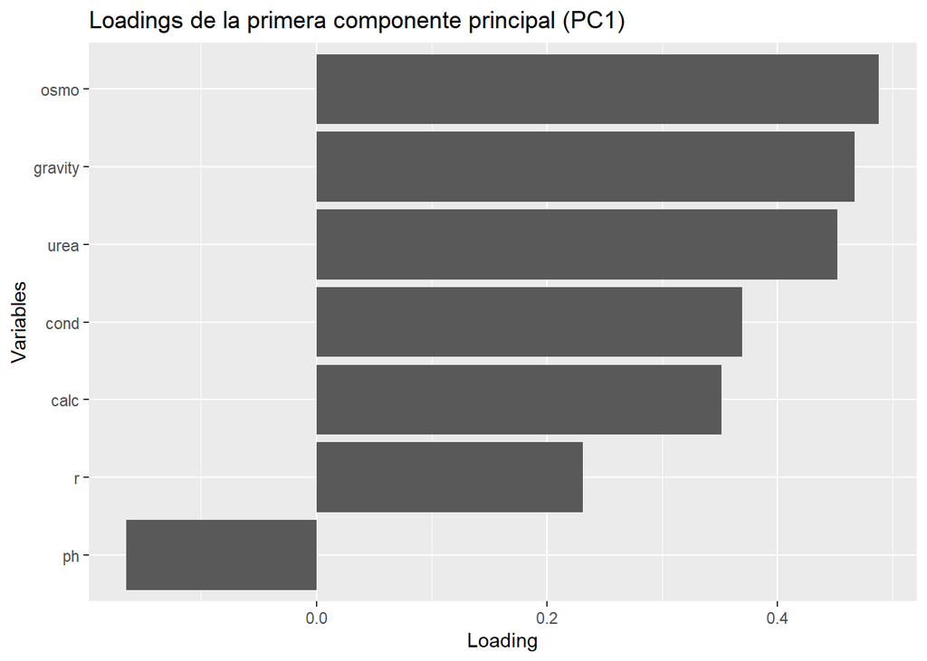

```r
# Si quieres graficar los loadings para visualización más clara:
library(ggplot2)

# Convertir los loadings a un formato adecuado para ggplot
loadings_df <- as.data.frame(loadings)
loadings_df$Variable <- rownames(loadings)

# Graficar los loadings para la primera componente
ggplot(loadings_df, aes(x = reorder(Variable, PC1), y = PC1)) +
  geom_bar(stat = "identity") +
  coord_flip() +
  labs(title = "Loadings de la primera componente principal (PC1)", x = "Variables", y = "Loading")
```

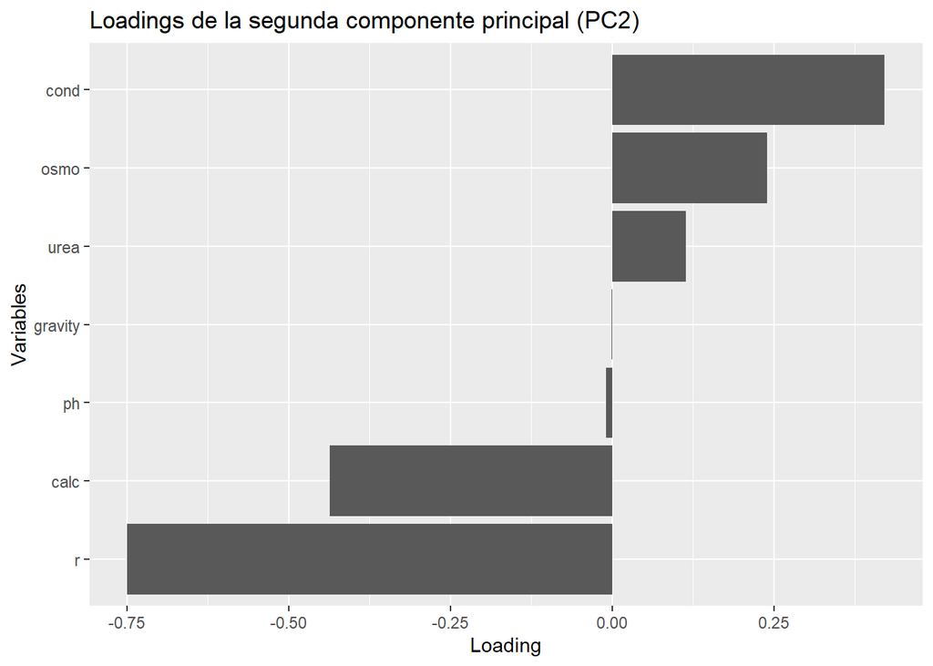

```r
# Graficar los loadings para la segunda componente
ggplot(loadings_df, aes(x = reorder(Variable, PC2), y = PC2)) +
  geom_bar(stat = "identity") +
  coord_flip() +
  labs(title = "Loadings de la segunda componente principal (PC2)", x = "Variables", y = "Loading")
```

## EJERCICIO 2

```
##                   Specie     CH    PLI     CI    NS    CL     CT   SI    SPI
## 1        Northern.fulmar      0 124000      0     0     0      0  224    700
## 2   Glaucous-winged.gull    150    400    150   274    50    300    0      0
## 3 Black-legged.kittiwake  40000  58000  60000  7550 25000  26500 5000  31000
## 4   Red-legged.kittiwake      0      0      0     0     0      0    0   2200
## 5     Thick-billed.murre 280000 172000 320000   400 30000 233578    0 110000
## 6           Common.murre      0      0      0 41800 70000 155719 5320  39000
##       SGI
## 1   70000
## 2       0
## 3   72000
## 4  220000
## 5 1500000
## 6  190000
```

Observamos el head del dataset. En las filas se indican las especies y en las columnas las diferentes colonias.

```
##     Specie                CH              PLI               CI
##  Length:23          Min.   :     0   Min.   :     0   Min.   :     0
##  Class :character   1st Qu.:     0   1st Qu.:     0   1st Qu.:     0
##  Mode  :character   Median :     0   Median :     0   Median :     0
##                     Mean   : 13928   Mean   : 15757   Mean   : 16537
##                     3rd Qu.:     0   3rd Qu.:     0   3rd Qu.:     0
##                     Max.   :280000   Max.   :172000   Max.   :320000
##        NS                CL              CT               SI
##  Min.   :    0.0   Min.   :    0   Min.   :     0   Min.   :     0
##  1st Qu.:    0.0   1st Qu.:    0   1st Qu.:     0   1st Qu.:     0
##  Median :    0.0   Median :    0   Median :     0   Median :    28
##  Mean   : 2340.6   Mean   : 5512   Mean   : 18159   Mean   : 14423
##  3rd Qu.:  169.5   3rd Qu.:   64   3rd Qu.:    30   3rd Qu.:  5160
##  Max.   :41800.0   Max.   :70000   Max.   :233578   Max.   :260000
##       SPI              SGI
##  Min.   :     0   Min.   :      0
##  1st Qu.:     0   1st Qu.:      0
##  Median :     0   Median :      0
##  Mean   : 11035   Mean   : 109522
##  3rd Qu.:  5200   3rd Qu.:  71000
##  Max.   :110000   Max.   :1500000
```

Observamos en el summary que no hay missin values

### A)

```r
# Calcular el total de todos los valores
total_sum <- sum(seabirds[,-1])

# Calcular las frecuencias relativas
freq_rel <- seabirds
freq_rel[,-1] <- seabirds[,-1] / total_sum

# Calcular las frecuencias relativas marginales de filas y columnas
freq_rel_marginals_rows <- rowSums(seabirds[,-1]) / total_sum
freq_rel_marginals_cols <- colSums(seabirds[,-1]) / total_sum

# Crear la matriz de perfiles
profile_matrix <- seabirds
profile_matrix[,-1] <- sweep(seabirds[,-1], 1, rowSums(seabirds[,-1]), FUN = "/")

list(
  frecuencias_relativas = freq_rel,
  frecuencias_relativas_marginales_filas = freq_rel_marginals_rows,
  frecuencias_relativas_marginales_columnas = freq_rel_marginals_cols,
  matriz_de_perfiles = profile_matrix
)
```

```
## $frecuencias_relativas
##                      Specie           CH          PLI           CI           NS
## 1           Northern.fulmar 0.000000e+00 2.601823e-02 0.000000e+00 0.000000e+00
## 2      Glaucous-winged.gull 3.147367e-05 8.392978e-05 3.147367e-05 5.749190e-05
## 3    Black-legged.kittiwake 8.392978e-03 1.216982e-02 1.258947e-02 1.584175e-03
## 4      Red-legged.kittiwake 0.000000e+00 0.000000e+00 0.000000e+00 0.000000e+00
## 5        Thick-billed.murre 5.875084e-02 3.608980e-02 6.714382e-02 8.392978e-05
## 6              Common.murre 0.000000e+00 0.000000e+00 0.000000e+00 8.770662e-03
## 7           Black.guillemot 4.196489e-05 1.678596e-03 4.196489e-05 0.000000e+00
## 8          Pigeon.guillemot 0.000000e+00 0.000000e+00 0.000000e+00 0.000000e+00
## 9             Horned.puffin 0.000000e+00 0.000000e+00 0.000000e+00 6.685007e-04
## 10            Tufted.puffin 0.000000e+00 0.000000e+00 0.000000e+00 8.602802e-06
## 11          Atlantic.puffin 0.000000e+00 0.000000e+00 0.000000e+00 0.000000e+00
## 12        Pelagic.cormorant 0.000000e+00 0.000000e+00 0.000000e+00 1.086891e-04
## 13      Red-faced.cormorant 0.000000e+00 0.000000e+00 0.000000e+00 0.000000e+00
```

[output cut: 97 more lines]

En la matriz de frecuencias relativas, observamos la frecuencia relativa de cada especie en cada colonia en relación con la presencia total de especies en todas las colonias. Esto nos permite entender la distribución proporcional de las especies a través de las colonias.

En la matriz de perfiles de las filas, analizamos la proporción de cada especie en las 9 colonias. Esto nos proporciona información sobre la abundancia relativa de cada especie en las diferentes colonias. Por ejemplo, podemos observar que el 63.6% de los individuos de la especie Northern fulmar se encuentran en la colonia PLI, lo que refleja su preferencia o mayor concentración en esa colonia en particular.

### B)

```r
# 1. Calcular el total de cada columna (frecuencia marginal de columnas)
col_totals <- colSums(seabirds[,-1])

# 2. Calcular la matriz de perfiles de columnas
profile_columns <- sweep(seabirds[,-1], 2, col_totals, FUN = "/")

# 3. Calcular las distancias chi-cuadrado entre columnas
# La distancia chi-cuadrado entre dos columnas A y B es:
# distancia(A, B) = sum( ( (p_iA - p_iB)^2 ) / p_i )
# donde p_iA y p_iB son los perfiles de las filas en las columnas A y B, y p_i es el promedio de perfiles.

# Calcular las frecuencias relativas marginales de filas
row_totals <- rowSums(seabirds[,-1])
total_sum <- sum(row_totals)
row_marginals <- row_totals / total_sum

# Inicializar matriz de distancias
distances <- matrix(0, ncol = ncol(profile_columns), nrow = ncol(profile_columns))
colnames(distances) <- colnames(profile_columns)
rownames(distances) <- colnames(profile_columns)

# Calcular la distancia chi-cuadrado entre cada par de columnas
for (i in 1:ncol(profile_columns)) {
  for (j in i:ncol(profile_columns)) {
    dist <- sum(((profile_columns[,i] - profile_columns[,j])^2) / row_marginals)
    distances[i, j] <- dist
    distances[j, i] <- dist
  }
}

# 4. Calcular la inercia total
inertia_total <- sum(distances * col_totals / total_sum) / 2

# Resultados
list(
  matriz_de_distancias = distances,
  inercia_total = inertia_total
)
```

```
## $matriz_de_distancias
##              CH       PLI          CI        NS         CL         CT       SI
## CH   0.00000000  3.425238  0.01780945  8.251115  3.7234212  1.5564260 15.46510
## PLI  3.42523758  0.000000  3.36473553 10.407262  6.1401304  4.6055964 17.75168
## CI   0.01780945  3.364736  0.00000000  8.154352  3.5963874  1.5964295 15.48546
## NS   8.25111471 10.407262  8.15435178  0.000000  1.5595341  3.2777270 20.80417
## CL   3.72342119  6.140130  3.59638742  1.559534  0.0000000  0.7664893 17.24585
## CT   1.55642598  4.605596  1.59642952  3.277727  0.7664893  0.0000000 15.71938
## SI  15.46509697 17.751675 15.48546304 20.804173 17.2458462 15.7193804  0.00000
## SPI  1.37256236  4.137466  1.34075056  5.731992  2.4287149  1.3213094 15.39261
## SGI  0.81590599  3.491713  0.89341794  6.974646  3.2811626  1.3394868 15.06801
##            SPI        SGI
## CH   1.3725624  0.8159060
## PLI  4.1374664  3.4917128
## CI   1.3407506  0.8934179
## NS   5.7319920  6.9746456
## CL   2.4287149  3.2811626
## CT   1.3213094  1.3394868
## SI  15.3926081 15.0680100
## SPI  0.0000000  0.5942528
## SGI  0.5942528  0.0000000
##
## $inercia_total
## [1] 20.83653
```

La matriz de distancias sobre los perfiles de las columnas nos permite comparar los perfiles de distribución de especies en cada colonia. Esto proporciona información sobre las diferencias en las distribuciones de especies entre las colonias. Un análisis rápido revela que las colonias con la mayor distancia entre sus perfiles son NS-SI, con un valor de 20.8. Esto indica que estas dos colonias presentan las distribuciones de especies más diferentes entre sí.

Por otro lado, la inercia total mide la cantidad total de variabilidad existente en las distribuciones de especies entre las colonias. Con una inercia total de 20.8, obtenemos un valor moderado, lo que sugiere que hay cierta variabilidad en la distribución de especies entre las diferentes colonias. Sin embargo, para explorar y entender en profundidad las causas de estas diferencias, son necesarios análisis más avanzados, como el Análisis de Correspondencias o el Escalado Multidimensional.

### C)

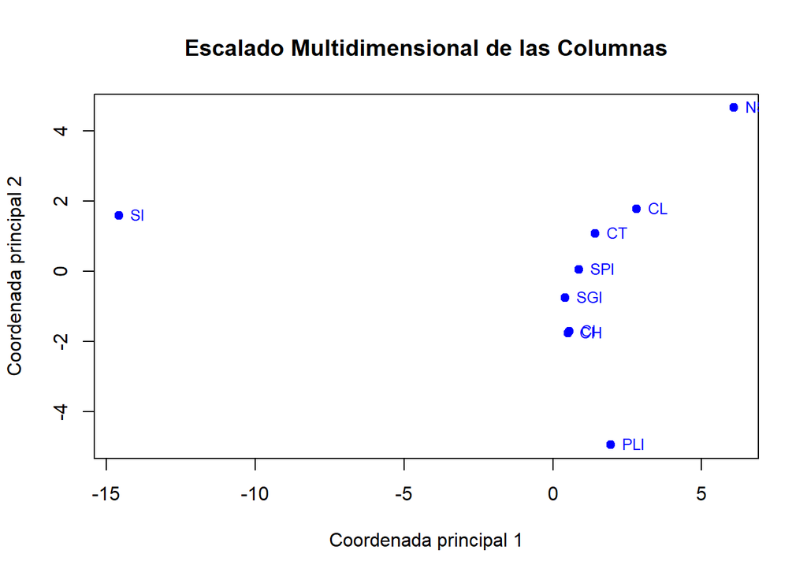

```r
# Realizar el escalado multidimensional en 2 dimensiones
mds_result <- cmdscale(distances, k = 2, eig = TRUE)

# Extraer las coordenadas principales
mds_coordinates <- mds_result$points

# Dibujar las coordenadas principales
plot(
  mds_coordinates[,1], mds_coordinates[,2],
  xlab = "Coordenada principal 1",
  ylab = "Coordenada principal 2",
  main = "Escalado Multidimensional de las Columnas",
  pch = 19, col = "blue"
)

# Agregar etiquetas a los puntos para identificar las columnas
text(mds_coordinates[,1], mds_coordinates[,2], labels = colnames(distances), pos = 4, cex = 0.8, col = "blue")
```

En este escalado multidimensional vemos las distancias entre las colonias representadas en dos coordenadas principales que forman un gráfico 2D.

Esto nos permite observar visualmente las distáncias entre las colonias y apreciar que colonias tienen una distribución de especies más diferentes. Las colonias que presentan una mayor distancia son SI-NS (20.8), tal y como hemos mencionado en el apartado anterior y concuerda con los resultados de la matriz de distancias de los perfiles de las columnas. SI-PLI también tienen una gran distancia (17.75).

Podemos observar en el gráfico que las colonias con una distribución de especies más diferente es SI, ya que es la que tiene una mayor distancia respecto al resto de colonias, aunque PLI y NS también estan apartadas de el resto de colonias y por lo tanto demuestran una distribución de espécies peculiar, más diferente a el resto de colonias que están más juntas entre ellas.

### D)

```r
library(ca)

# Crear la tabla de contingencia de frecuencias (donde las especies están en filas y las colonias en columnas)
tabla_contingencia <- as.data.frame.matrix(seabirds[, -1])  # Excluye la primera columna (las especies)
row.names(tabla_contingencia) <- seabirds$Specie  # Asigna las especies como nombres de filas

# Realizar el Análisis de Correspondencias
ca_result <- ca(tabla_contingencia)

# Ver los resultados del CA
summary(ca_result)
```

```
##
## Principal inertias (eigenvalues):
##
##  dim    value      %   cum%   scree plot
##  1      0.966250  61.7  61.7  ***************
##  2      0.256639  16.4  78.1  ****
##  3      0.205925  13.2  91.3  ***
##  4      0.098617   6.3  97.6  **
##  5      0.026177   1.7  99.2
##  6      0.008313   0.5  99.8
##  7      0.003765   0.2 100.0
##  8      6e-06000   0.0 100.0
##         -------- -----
##  Total: 1.565692 100.0
##
```

[output cut: 38 more lines]

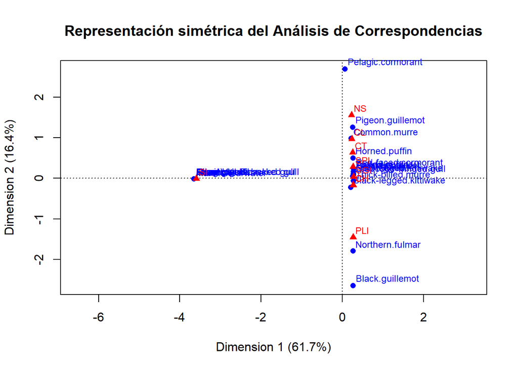

```r
# Graficar la representación simétrica del CA
plot(ca_result, main = "Representación simétrica del Análisis de Correspondencias",
     what = "all")
```

```r
# Ver las coordenadas de las columnas (incluyendo SI)
ca_result$colnames
```

```
## [1] "CH"  "PLI" "CI"  "NS"  "CL"  "CT"  "SI"  "SPI" "SGI"
```

```r
ca_result$rowcoord  # Coordenadas de las especies (filas)
```

```
##                                Dim1        Dim2         Dim3         Dim4
## Northern.fulmar           0.2744375 -3.53346860 -2.083643578  1.973514556
## Glaucous-winged.gull      0.2640363  0.10791466 -3.759522889 -0.306756785
## Black-legged.kittiwake    0.2126175 -0.43501319 -1.151515130 -1.307392246
## Red-legged.kittiwake      0.2836973  0.16422644  1.389196013  1.673780633
## Thick-billed.murre        0.2796644 -0.11729005  0.315325104 -0.612508491
## Common.murre              0.2244936  1.94420038 -1.916422839  0.695262726
## Black.guillemot           0.2758766 -5.22404843 -3.890796577  1.669111555
## Pigeon.guillemot          0.2636924  2.47770421 -2.986074559 -1.620243200
## Horned.puffin             0.2760710  0.97820391 -0.004958317  1.772776159
## Tufted.puffin             0.2818398  0.33350942  1.140735968  1.702026616
## Atlantic.puffin          -3.7191865 -0.03188225  0.065759413  0.007940309
## Pelagic.cormorant         0.0712205  5.30067263 -7.409365949  3.776777399
## Red-faced.cormorant       0.2801373  0.47040667  0.970298183  1.706627989
## Shag                     -3.7191865 -0.03188225  0.065759413  0.007940309
## Parakeet.auklet           0.2817552  0.33180686  1.159308699  1.692716467
## Crested.auklet            0.2818639  0.32191110  1.173461116  1.690697218
## Least.auklet              0.2828790  0.23460876  1.292903060  1.681331326
## Razorbill                -3.7191865 -0.03188225  0.065759413  0.007940309
## Manx.shearwater          -3.7191865 -0.03188225  0.065759413  0.007940309
## Storm.petrel             -3.7191865 -0.03188225  0.065759413  0.007940309
## Herring.gull             -3.7191865 -0.03188225  0.065759413  0.007940309
## Great.black-backed.gull  -3.7191865 -0.03188225  0.065759413  0.007940309
## Lesser.black.backed.gull -3.7191865 -0.03188225  0.065759413  0.007940309
##                                 Dim5         Dim6          Dim7          Dim8
## Northern.fulmar          -0.59704588   0.32451845  -0.469270028 -8.859425e-01
## Glaucous-winged.gull     -0.87298734 -12.76860941 -12.785256724 -1.907174e+01
## Black-legged.kittiwake    2.18568075  -0.97363542   2.134393276 -3.197064e-01
## Red-legged.kittiwake     -1.58316421  -1.18857124   2.350801862 -1.488914e-01
## Thick-billed.murre       -0.31248268   0.10345148  -0.348113307  5.254503e-02
## Common.murre             -0.45632904   0.54017152   0.009793559 -1.538014e-02
## Black.guillemot           0.12756558   0.89033418  -0.431376492  1.587349e+01
## Pigeon.guillemot         -7.71622758  19.72562679 -20.351861994 -2.294025e+02
## Horned.puffin             1.38787094  -5.17221210  -2.164743079  5.077965e+00
## Tufted.puffin             1.81454795   0.14586145  -0.434888664  8.599813e-01
## Atlantic.puffin          -0.02689777   0.01122369  -0.030488541  7.189874e-03
## Pelagic.cormorant         1.35424846 -58.99560859 -30.904693612 -1.536714e+01
## Red-faced.cormorant       6.66353586   3.15471285  -4.266996386 -3.801887e-01
## Shag                     -0.02689777   0.01122369  -0.030488541  7.189874e-03
## Parakeet.auklet           2.87546895   1.13168951  -1.244680295 -3.035276e-01
## Crested.auklet            2.66393583   1.04824614  -1.057403958 -2.680109e-01
## Least.auklet              0.31252262  -0.19017111   0.829554227 -2.020603e-01
## Razorbill                -0.02689777   0.01122369  -0.030488541  7.189874e-03
## Manx.shearwater          -0.02689777   0.01122369  -0.030488541  7.189874e-03
## Storm.petrel             -0.02689777   0.01122369  -0.030488541  7.189874e-03
## Herring.gull             -0.02689777   0.01122369  -0.030488541  7.189874e-03
## Great.black-backed.gull  -0.02689777   0.01122369  -0.030488541  7.189874e-03
## Lesser.black.backed.gull -0.02689777   0.01122369  -0.030488541  7.189874e-03
```

El gráfico del análisis de correspondencia concuerda bastante con el escalado multidimensional del apartado anterior, ya que SI es la colonia más alejada del resto, y por lo tanto la más diferente. PLI también está bastante lejos del grueso de colonias, aunque NS no gurarda una distancia tan grande como en el gráfico anterior.

Las inercias principales son los valores propios (eigenvalues) calculados durante el análisis de correspondencias. En el contexto del CA, estos valores representan la varianza explicada por cada componente o dimensión (dimensiones que se obtienen al descomponer la tabla de contingencia).

La primera dimension explica 61.7% de la variabilidad total en los datos, lo que significa que la mayor parte de la información relevante del análisis se encuentra en esta dimensión. La segunda dimensión explica el 16.4% de la variabilidad total. Juntas, las dos primeras dimensiones explican aproximadamente el 78% de la variabilidad en los datos.

```
## [1] 136
```

Hay 136 valores igual a cero en la tabla de contingencia, esto podría estar afectando considerablemente los resultados del Análisis de Correspondencias (CA), ya que la inercia total puede no ser significativa si las celdas no contienen suficientes datos informativos.

```r
ca_result$colcoord["SI", ]
```

```
##          Dim1          Dim2          Dim3          Dim4          Dim5
## -3.655886e+00 -1.615139e-02  2.984093e-02  2.493526e-03 -4.351876e-03
##          Dim6          Dim7          Dim8
##  1.023320e-03 -1.870776e-03  1.774949e-05
```

```r
# Coordenadas de la colonia SI
coords_SI <- ca_result$colcoord["SI", ]

# Calcular la distancia euclidiana entre las coordenadas de las especies y la colonia SI
distancias <- apply(ca_result$rowcoord, 1, function(x) sqrt(sum((x - coords_SI)^2)))

# Ordenar las especies por la distancia más corta
especies_caracteristicas_SI <- sort(distancias)

# Mostrar las especies más cercanas a la colonia SI
especies_caracteristicas_SI
```

```
##             Herring.gull             Storm.petrel Lesser.black.backed.gull
##               0.08400583               0.08400583               0.08400583
##                Razorbill                     Shag          Manx.shearwater
##               0.08400583               0.08400583               0.08400583
##          Atlantic.puffin  Great.black-backed.gull       Thick-billed.murre
##               0.08400583               0.08400583               4.02325676
##             Least.auklet             Common.murre            Tufted.puffin
##               4.56723565               4.86451801               4.89968009
##   Black-legged.kittiwake           Crested.auklet     Red-legged.kittiwake
##               5.35389752               5.40189642               5.44600102
##          Parakeet.auklet          Northern.fulmar            Horned.puffin
##               5.56481216               6.13433193               8.87402685
##      Red-faced.cormorant          Black.guillemot     Glaucous-winged.gull
##               9.60520126              17.71128906              26.84773893
##        Pelagic.cormorant         Pigeon.guillemot
##              69.17607450             231.34708118
```

Las especies que caracterizan a la colonia SI (Skomer Island) son aquellas que tienen una distancia euclidiana más cercana a la colonia, en este caso, de 0.084 unidades. Estas especies incluyen:

Herring gull Storm petrel Lesser black-backed gull Razorbill Shag Manx shearwater Atlantic puffin Great black-backed gull

Estas especies están más cercanas en el espacio de coordenadas multivariantes, lo que sugiere que tienen una fuerte asociación con la colonia SI y son representativas de su comunidad ecológica.

### E)

```r
# Crear la tabla de contingencia como antes
colonias <- seabirds[, -1]  # Excluir la columna de especies

# Convertir a formato de tabla de contingencia
tabla_contingencia_colonias <- as.data.frame.matrix(colonias)

# Transponer la tabla para tener las colonias en filas y columnas
tabla_contingencia_colonias <- t(tabla_contingencia_colonias)

# Calcular la matriz de distancias de Canberra
distancia_canberra <- dist(tabla_contingencia_colonias, method = "canberra")

# Mostrar la matriz de distancias
print(distancia_canberra)
```

```
##            CH       PLI        CI        NS        CL        CT        SI
## PLI 13.010532
## CI   1.533333 12.528225
## NS  20.372989 20.589473 20.614179
## CL  16.152618 20.027180 16.736574 15.104240
## CT  16.064104 17.036525 16.782859 16.959232 13.091008
## SI  22.659259 22.751084 22.764103 21.477693 21.643136 21.457257
## SPI 20.457010 20.367388 20.889402 18.954040 18.774626 19.213291 21.846897
## SGI 21.179652 19.780533 20.769461 21.638100 21.031434 20.225132 22.780667
##           SPI
## PLI
## CI
## NS
## CL
## CT
## SI
## SPI
## SGI 16.238432
```

La fórmula clásica de la distancia de Canberra puede no funcionar en el caso de la tabla 12.7 del libro de Krebs si existen muchas entradas en las cuales tanto pi como qi son cero, lo que lleva a valores indefinidos o NaN. Esto es común en datos con muchos ceros o datos dispersos, como los que podrían estar presentes en tablas de frecuencias o abundancias de especies (que a menudo tienen muchos ceros para especies no observadas en determinadas ubicaciones).

En la tabla los valores reflejan las diferencias relativas en la presencia de especies entre las colonias, con valores más pequeños que sugieren colonias más similares y valores más grandes que indican disimilitudes mayores.

La tabla 12.7 del libro de Krebs presenta una matriz de distancias similar, y se observa que la distancia de Canberra es adecuada para los datos con una gran cantidad de ceros. La fórmula utilizada en R permite manejar correctamente estos ceros, lo que hace que la comparación entre las colonias sea válida y coherente tal y como se muestra en la tabla.

```r
library(vegan)

# Paso 1: Calcular la matriz de distancias de Canberra
dist_canberra <- dist(tabla_contingencia_colonias, method = "canberra")

# Paso 2: Realizar MDS utilizando la distancia de Canberra
mds_canberra <- metaMDS(dist_canberra)
```

```
## *** Best solution repeated 1 times
```

```r
# Ver los resultados del MDS de Canberra
mds_canberra$points
```

```
##          MDS1       MDS2
## CH  -2.620987 -4.6589587
## PLI -4.457683 -3.7940041
## CI  -3.200682 -4.6872792
## NS   3.476855  4.1990630
## CL   1.615150  0.5381485
## CT   1.633472 -1.3104388
## SI  13.963453 -0.6792870
## SPI -2.121768  6.1894158
## SGI -8.287810  4.2033405
## attr(,"centre")
## [1] TRUE
## attr(,"pc")
## [1] TRUE
## attr(,"halfchange")
## [1] FALSE
## attr(,"internalscaling")
## [1] 0.1403853
```

```r
# Visualizamos el análisis de MDS de la distancia de Canberra
#plot(mds_canberra, type = "t", main = "MDS con Distancia de Canberra")

# Paso 3: Calcular la matriz de distancias Ji-cuadrado usando vegdist()
dist_chi_square <- vegdist(tabla_contingencia_colonias, method = "chisq")

# Realizar el MDS con la distancia Ji-cuadrado
mds_chi_square <- metaMDS(dist_chi_square)
```

```
## *** Best solution repeated 1 times
```

```r
# Visualizar el MDS de Ji-cuadrado
#plot(mds_chi_square, type = "t", main = "MDS con Distancia Ji-Cuadrado")

# Paso 4: Usar la función procrustes() para comparar los dos mapas de MDS
procrustes_result <- procrustes(mds_canberra, mds_chi_square)

# Mostrar los resultados de Procrustes
procrustes_result
```

```
##
## Call:
## procrustes(X = mds_canberra, Y = mds_chi_square)
##
## Procrustes sum of squares:
## 236.6
```

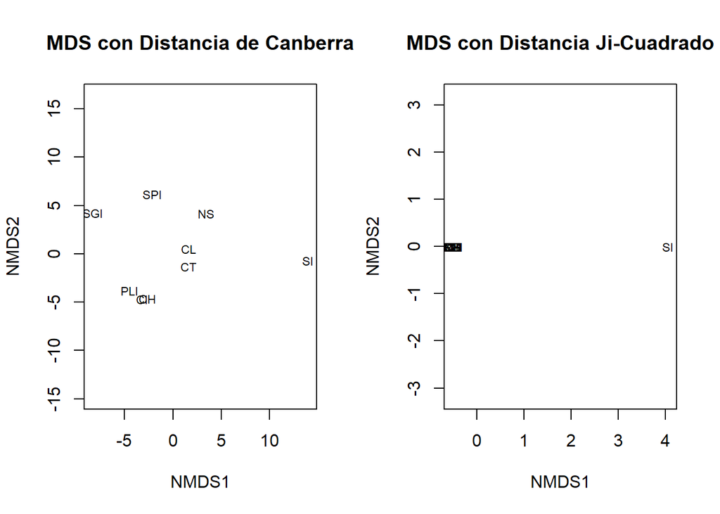

```r
# Paso 5: Graficar ambos MDS en un mismo gráfico para comparación
par(mfrow = c(1, 2))  # Para colocar los gráficos uno al lado del otro
plot(mds_canberra, type = "t", main = "MDS con Distancia de Canberra")
plot(mds_chi_square, type = "t", main = "MDS con Distancia Ji-Cuadrado")
```

El gráfico comparativo del MDS de la distancia de Canberra con la distancia Ji-cuadrado nos permite afirmar que la distancia de Canberra resulta ser más adecuada para representar este tipo de datos porque esta distancia es particularmente sensible a pequeñas variaciones, lo que permite una representación más clara de las relaciones sutiles entre las colonias. Además, la normalización de las distancias en la fórmula de Canberra ayuda a evitar que las diferencias absolutas en las frecuencias de especies dominantes influyan demasiado en los resultados, lo que permite que las colonias más pequeñas o con menos especies también se representen de manera adecuada.

Por otro lado, la distancia Ji-cuadrado tiende a dar mayor peso a las diferencias en frecuencias absolutas y no es tan sensible a las pequeñas diferencias relativas. Esto puede llevar a una dispersión excesiva en el gráfico de MDS, donde las colonias con pequeñas diferencias entre ellas se agrupan o “apelotonan”, y no reflejan bien las verdaderas relaciones ecológicas entre las colonias. Es decir, la distancia Ji-cuadrado tiende a exagerar las diferencias entre colonias que tienen frecuencias de especies muy dispares, mientras que con la distancia de Canberra se conservan mejor las similitudes entre colonias con diferencias menos marcadas.